# Homework 08

Use either R or Python.

## Question 1: Boundary and margin

Use `margin-geometry-20.csv`, which contains 20 observations with predictors $x_1, x_2$ and class labels $y \in \{-1,1\}$. Consider the score

$$f(x)=0.8x_1+0.6x_2.$$

Since $\|(0.8,0.6)\|_2=1$, the lines $f(x)=\pm 1$ are each a distance 1 from the decision boundary $f(x)=0$.

### Solution

The distance from each observation to the decision boundary is $|f(x)|$, and the functional margin is $y f(x)$. Observations are:

- inside the margin if $0 < y f(x) < 1$;
- on the margin if $y f(x)=1$;
- beyond the margin if $y f(x)>1$;
- misclassified if $y f(x)<0$.

**Show the R code**

```r
df <- read.csv("data/margin-geometry-20.csv")
df$f <- 0.8 * df$x1 + 0.6 * df$x2
df$distance <- abs(df$f)
df$yf <- df$y * df$f
df$status <- ifelse(
  df$yf < 0, "misclassified",
  ifelse(abs(df$yf - 1) < 1e-8, "on margin",
         ifelse(df$yf > 1, "beyond margin", "inside margin"))
)

print(df[, c("observation", "x1", "x2", "y", "f", "distance", "yf", "status")])
```

```
   observation    x1    x2  y     f distance    yf        status
1            1  0.68  0.76  1  1.00     1.00  1.00     on margin
2            2  1.80 -0.15  1  1.35     1.35  1.35 beyond margin
3            3  1.38  0.66  1  1.50     1.50  1.50 beyond margin
4            4  0.88  1.66  1  1.70     1.70  1.70 beyond margin
5            5  0.62  2.34  1  1.90     1.90  1.90 beyond margin
6            6  2.78 -0.04  1  2.20     2.20  2.20 beyond margin
7            7  1.86  1.52  1  2.40     2.40  2.40 beyond margin
8            8  0.50  0.40  1  0.64     0.64  0.64 inside margin
9            9  0.10  0.20  1  0.20     0.20  0.20 inside margin
10          10 -0.40  0.20  1 -0.20     0.20 -0.20 misclassified
11          11 -0.92 -0.44 -1 -1.00     1.00  1.00     on margin
12          12 -0.50 -1.50 -1 -1.30     1.30  1.30 beyond margin
13          13 -1.90 -0.05 -1 -1.55     1.55  1.55 beyond margin
14          14 -0.44 -2.33 -1 -1.75     1.75  1.75 beyond margin
15          15 -1.98 -0.61 -1 -1.95     1.95  1.95 beyond margin
16          16 -2.74  0.07 -1 -2.15     2.15  2.15 beyond margin
17          17 -1.90 -1.55 -1 -2.45     2.45  2.45 beyond margin
18          18 -0.50 -0.40 -1 -0.64     0.64  0.64 inside margin
19          19  0.00 -0.40 -1 -0.24     0.24  0.24 inside margin
20          20  0.40 -0.20 -1  0.20     0.20 -0.20 misclassified
```

**Show the R code**

```r
print(table(df$status))
```

```
beyond margin inside margin misclassified     on margin
           12             4             2             2
```

**Show the R code**

```r
cat("Misclassified observation numbers:",
    paste(df$observation[df$yf < 0], collapse = ", "), "\n")
```

```
Misclassified observation numbers: 10, 20
```

The resulting counts are:

- inside margin: 4
- on margin: 2
- beyond margin: 12
- misclassified: 2

The misclassified observations are 10 and 20.

#### Plot of the decision boundary and margin lines

**Show the R code**

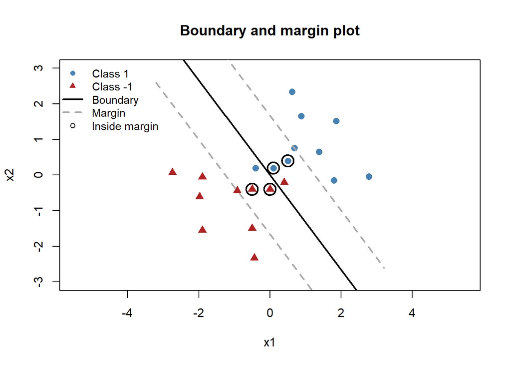

```r
x_grid <- seq(-3.2, 3.2, length.out = 200)

plot(NA,
     xlim = c(-3.2, 3.2),
     ylim = c(-3, 3),
     xlab = "x1",
     ylab = "x2",
     asp = 1,
     main = "Boundary and margin plot")

points(df$x1[df$y == 1], df$x2[df$y == 1], pch = 16, col = "steelblue",
       cex = 1.2)
points(df$x1[df$y == -1], df$x2[df$y == -1], pch = 17, col = "firebrick",
       cex = 1.2)

# Decision boundary f(x) = 0
curve((0 - 0.8 * x) / 0.6, from = -3.2, to = 3.2, add = TRUE,
      col = "black", lwd = 2)
# Margin lines f(x) = 1 and f(x) = -1
curve((1 - 0.8 * x) / 0.6, from = -3.2, to = 3.2, add = TRUE,
      col = "darkgray", lwd = 2, lty = 2)
curve((-1 - 0.8 * x) / 0.6, from = -3.2, to = 3.2, add = TRUE,
      col = "darkgray", lwd = 2, lty = 2)

inside <- subset(df, status == "inside margin")
points(inside$x1, inside$x2, pch = 1, cex = 2.2, lwd = 2, col = "black")

legend("topleft",
       legend = c("Class 1", "Class -1", "Boundary", "Margin", "Inside margin"),
       pch = c(16, 17, NA, NA, 1),
       lty = c(NA, NA, 1, 2, NA),
       col = c("steelblue", "firebrick", "black", "darkgray", "black"),
       lwd = c(NA, NA, 2, 2, NA),
       cex = 0.9,
       bty = "n")
```

Observations inside the margin are the ones with $0 < y f(x) < 1$. In the plot, they are marked with a black outline around the point.

## Question 2: Margin in four dimensions

Use `margin-geometry-4d.csv`, which contains 50 observations with four predictors and class labels $y \in \{-1,1\}$. Consider the score

$$f(\mathbf{x}) = \beta_0 + \mathbf{x}^{\mathsf T}\boldsymbol{\beta},
\qquad
\beta_0 = -1,
\quad
\boldsymbol{\beta} = (1,2,-2,4)^{\mathsf T}.$$

### Solution

Let

$$\boldsymbol{\beta} = (1,2,-2,4)^{\mathsf T},
\quad
\|\boldsymbol{\beta}\|_2 = \sqrt{1^2+2^2+(-2)^2+4^2} = \sqrt{25}=5.$$

The geometric margin is

$$M = \frac{\min_i |\beta_0 + \mathbf{x}_i^{\mathsf T}\boldsymbol{\beta}|}{\|\boldsymbol{\beta}\|_2}.$$

For these data, the closest score is 5 units away from the boundary, so

$$M = \frac{5}{5} = 1.$$

The projection onto the direction of $\boldsymbol{\beta}$ is

$$\frac{\mathbf{x}^{\mathsf T}\boldsymbol{\beta}}{\|\boldsymbol{\beta}\|_2}.$$

The boundary is at the projected coordinate

$$\frac{-\beta_0}{\|\boldsymbol{\beta}\|_2} = \frac{1}{5}=0.2.$$

**Show the R code**

```r
df <- read.csv("data/margin-geometry-4d.csv")
X <- as.matrix(df[, c("x1", "x2", "x3", "x4")])
beta <- c(1, 2, -2, 4)
beta0 <- -1
score <- beta0 + X %*% beta
proj <- as.vector(X %*% beta / sqrt(sum(beta^2)))
df$score <- score
df$yf <- df$y * df$score
df$proj <- proj

M <- min(abs(df$score)) / sqrt(sum(beta^2))
cat("Geometric margin M =", M, "\n")
```

```
Geometric margin M = 1
```

**Show the R code**

```r
cat("Boundary position on the projected axis =", -beta0 / sqrt(sum(beta^2)), "\n")
```

```
Boundary position on the projected axis = 0.2
```

**Show the R code**

```r
cat("Smallest functional margin y_i f(x_i) =", min(df$yf), "\n")
```

```
Smallest functional margin y_i f(x_i) = 5
```

**Show the R code**

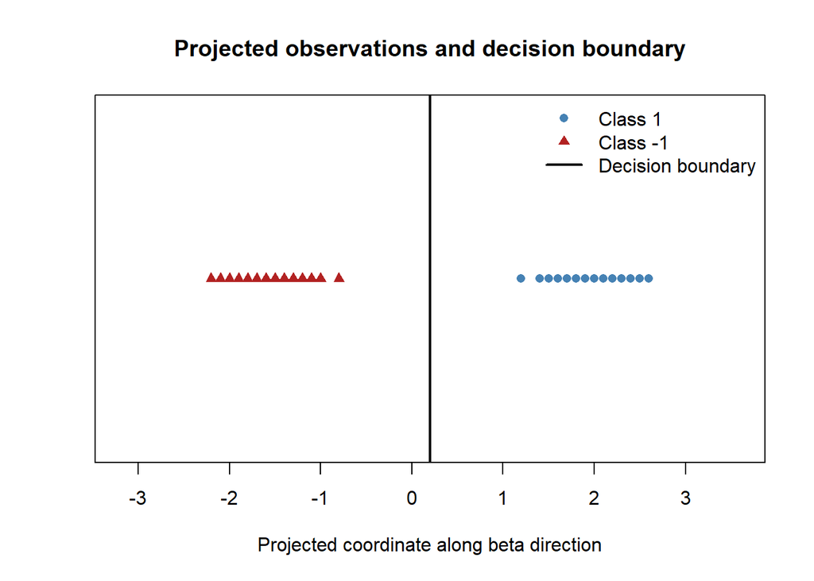

```r
plot(NA,
     xlim = c(min(df$proj) - 1, max(df$proj) + 1),
     ylim = c(-1, 1),
     xlab = "Projected coordinate along beta direction",
     ylab = "",
     yaxt = "n",
     main = "Projected observations and decision boundary")

points(df$proj[df$y == 1], rep(0, sum(df$y == 1)), pch = 16, col = "steelblue")
points(df$proj[df$y == -1], rep(0, sum(df$y == -1)), pch = 17, col = "firebrick")
abline(v = -beta0 / sqrt(sum(beta^2)), col = "black", lwd = 2)
legend("topright",
       legend = c("Class 1", "Class -1", "Decision boundary"),
       pch = c(16, 17, NA),
       lty = c(NA, NA, 1),
       col = c("steelblue", "firebrick", "black"),
       lwd = c(NA, NA, 2),
       bty = "n")
```

The same boundary in SVM normalization is obtained by setting the smallest functional margin equal to 1. Since the smallest value of $y_i f(x_i)$ is 5,

$$\boldsymbol{\beta}^{\star} = \frac{\boldsymbol{\beta}}{5} = (0.2, 0.4, -0.4, 0.8)^{\mathsf T},
\qquad
\beta_0^{\star} = \frac{-1}{5} = -0.2.$$

Thus the normalized form is

$$0.2x_1 + 0.4x_2 - 0.4x_3 + 0.8x_4 - 0.2 = 0.$$

## Question 3: Peer review of a Homework 7 skill

### Peer review

#### Overall assessment

The skill is clear and sets up the right protocol: a reserved test set, shared CV folds, and preprocessing fit inside each fold. My run followed it without leakage and produced a one-page report with every required element. My three suggestions are about places where the skill leaves too much open or could mislead.

#### 1. Selection ignores noise

**Observed.** Step 4 takes the lowest mean CV error across many candidates. In your report, QDA on 8 PCs won with 0.259 versus 0.272 for LDA, a difference of 1.3 percentage points, roughly equivalent to four cases out of 324 (the CV result is an average across folds, so this is approximate). The selected model then had a higher test error (0.290) than LDA (0.275).

**Why it matters.** Picking the minimum of many noisy estimates favors candidates that happened to do well on these folds, so the winner’s validation rate is optimistic.

**Recommendation.** Choose the simplest model within one standard error of the best, and define “simpler” as a full ordering.

#### 2. Key choices are unspecified

**Observed.** The skill does not set the test fraction, fold count, stratification, PCA scaling, range of d, or blend weight. Your report used a 30% test split with PCA and blend candidates. My run used 20% and compared only LDA and QDA, and we selected different models.

**Why it matters.** Results depend on the agent’s choices rather than on the skill. PCA scaling is a particular risk here, since SAheart variables differ widely in scale (variance about 0.2 for famhist versus about 600 for alcohol), and unscaled PCA would be dominated by the large-variance variables.

**Recommendation.** Set explicit defaults: stratified split, stratified 10-fold CV, standardization before PCA, a fixed range of d, and whether extensions are included by default.

#### 3. The report table conflicts with step 5

**Observed.** Step 5 says to evaluate the selected model once on the test set, but your Table 1 reports test error for all five models. My table showed test error only for the selected model.

**Why it matters.** Showing test errors for every candidate risks turning the test set into a second comparison set. Your report doesn’t show that test results were used to choose the model, but the layout invites that reading, and a 0.015 difference on 138 cases is about two observations.

**Recommendation.** Require validation error for all candidates but test error only for the selected one.

GitHub Issue: [Homework 8 review #4](https://github.com/conner-jensen/stat432-fall2026/issues/4)